# Goodreads (SAPunica)

2023-01-15

Radimo sa skupom podataka o knjigama na stranici goodreads.com

Za početak pogledajmo kako izgleda skup podataka:

```r
library(readr)
goodreads_dataset = read_csv("Goodreads-dataset-sanitized-arr.csv")
head(goodreads_dataset)
```

```
## # A tibble: 6 × 17
##   Column1 title series author rating langu…¹ genres bookF…² pages publi…³ awards
##     <dbl> <chr> <chr>  <chr>   <dbl> <chr>   <chr>  <chr>   <dbl> <chr>    <dbl>
## 1       0 Attr… <NA>   DiAnn…   4.14 English ['Chr… Paperb…   416 Tyndal…      1
## 2       1 Elem… Soul … Kim R…   4.07 English ['Fan… Kindle…   151 Kim Ri…      0
## 3       2 Unbe… Port … Sherr…   4.16 English ['Rom… Paperb…   360 Wordpa…      0
## 4       3 Frac… Fatef… Cheri…   4    English ['Vam… Nook        0 Cheri …      0
## 5       4 Anas… Sense… Emma …   4.19 English ['Mys… Paperb…   190 Bokhei…      0
## 6       5 Mark… Soul … Kim R…   3.7  English ['Fan… Paperb…   280 Create…      1
## # … with 6 more variables: numRatings <dbl>, ratingsByStars <chr>,
## #   likedPercent <dbl>, price <dbl>, genre1 <chr>, genre2 <chr>, and
## #   abbreviated variable names ¹language, ²bookFormat, ³publisher
```

```r
dim(goodreads_dataset)
```

```
## [1] 52478    17
```

Skup podataka sastoji se od 52478 primjerka, s po 17 atributa. Atributi su sljedeći:

```r
summary(goodreads_dataset)
```

```
##     Column1         title              series             author
##  Min.   :    0   Length:52478       Length:52478       Length:52478
##  1st Qu.:13119   Class :character   Class :character   Class :character
##  Median :26239   Mode  :character   Mode  :character   Mode  :character
##  Mean   :26239
##  3rd Qu.:39358
##  Max.   :52477
##
##      rating        language            genres           bookFormat
##  Min.   :0.000   Length:52478       Length:52478       Length:52478
##  1st Qu.:3.820   Class :character   Class :character   Class :character
##  Median :4.030   Mode  :character   Mode  :character   Mode  :character
##  Mean   :4.022
##  3rd Qu.:4.230
##  Max.   :5.000
##
##      pages          publisher             awards         numRatings
##  Min.   :    0.0   Length:52478       Min.   :0.0000   Min.   :      0
##  1st Qu.:  210.0   Class :character   1st Qu.:0.0000   1st Qu.:    341
##  Median :  304.0   Mode  :character   Median :0.0000   Median :   2307
##  Mean   :  328.7                      Mean   :0.2023   Mean   :  17879
##  3rd Qu.:  392.0                      3rd Qu.:0.0000   3rd Qu.:   9380
##  Max.   :14777.0                      Max.   :1.0000   Max.   :7048471
##  NA's   :2370
##  ratingsByStars      likedPercent        price            genre1
##  Length:52478       Min.   :  0.00   Min.   :  0.840   Length:52478
##  Class :character   1st Qu.: 90.00   1st Qu.:  3.240   Class :character
##  Mode  :character   Median : 94.00   Median :  5.200   Mode  :character
##                     Mean   : 92.23   Mean   :  9.657
##                     3rd Qu.: 96.00   3rd Qu.:  8.860
##                     Max.   :100.00   Max.   :898.640
##                     NA's   :622      NA's   :14377
##     genre2
##  Length:52478
##  Class :character
##  Mode  :character
##
##
##
##
```

U skupu podataka nalaze se i neke nedostajuće vrijednosti:

```r
sum(is.na(goodreads_dataset))
```

```
## [1] 55353
```

## Usporedba ocjena po žanrovima

Usporedimo prosječnu ocjenu za žanr fikcije u usporedbi s publicistikom

```r
fiction = goodreads_dataset[goodreads_dataset$genre1 == "Fiction",]
nonfiction = goodreads_dataset[goodreads_dataset$genre1 == "Nonfiction",]
cat("Means by genre:","\n")
```

```
## Means by genre:
```

```r
cat("Fiction:",mean(fiction$rating), "\n")
```

```
## Fiction: 3.975495
```

```r
cat("Non-fiction:",mean(nonfiction$rating))
```

```
## Non-fiction: 4.061082
```

Srednje vrijednosti se razlikuju, ali još trebamo utvrditi je li ova razlika statistički značajna.

Pogledajmo histograme ocjena:

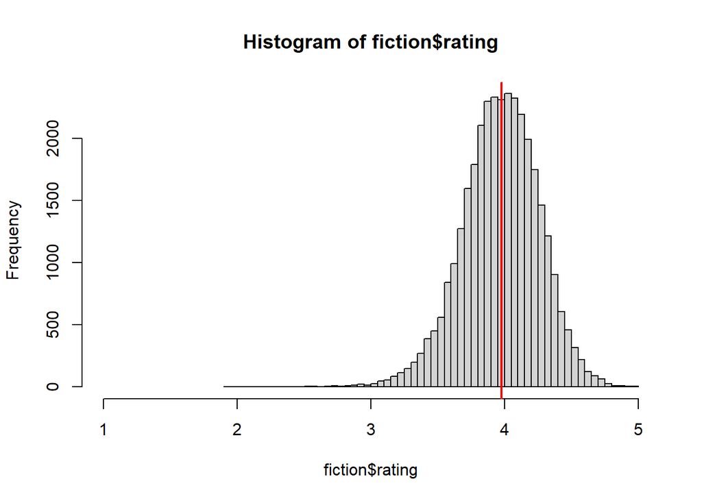

```r
hist(fiction$rating, breaks=50, xlim = c(1,5))
abline(v=mean(fiction$rating, na.rm = TRUE), col="red", lwd=2)
```

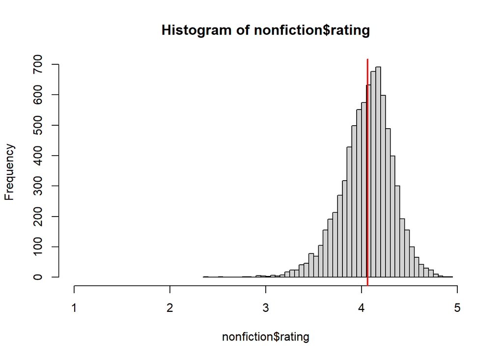

```r
hist(nonfiction$rating, breaks=50, xlim = c(1,5))
abline(v=mean(nonfiction$rating, na.rm = TRUE), col="red", lwd=2)
```

Prije provođenja T-testa, trebamo odrediti jesu li varijance jednake:

```r
var.test(fiction$rating, nonfiction$rating)
```

```
##
##  F test to compare two variances
##
## data:  fiction$rating and nonfiction$rating
## F = 1.1465, num df = 34104, denom df = 8050, p-value = 1.51e-14
## alternative hypothesis: true ratio of variances is not equal to 1
## 95 percent confidence interval:
##  1.107584 1.186346
## sample estimates:
## ratio of variances
##           1.146501
```

Varijance ova dva uzorka očito se značajno razlikuju, stoga će se u T-testu morati krenuti s pretpostavkom da su varijance te dvije populacije različite.

Također, iako T-test pretpostavlja da se podatci ravnaju po normalnoj razdiobi, daje dobre rezultate i kada razdioba podataka ponešto odstupa od normalne. Stoga, za ovu svrhu nećemo testirati normalnost podataka.

Radimo T-test:

```r
t.test(fiction$rating, nonfiction$rating, alternative = "less", var.equal = FALSE)
```

```
##
##  Welch Two Sample t-test
##
## data:  fiction$rating and nonfiction$rating
## t = -25.367, df = 12776, p-value < 2.2e-16
## alternative hypothesis: true difference in means is less than 0
## 95 percent confidence interval:
##         -Inf -0.08003736
## sample estimates:
## mean of x mean of y
##  3.975495  4.061082
```

Očito je da je prosječna ocjena knjiga iz fikcije značajno manja od dokumentarne literature

Pogledajmo usporedbu po drugoj kategoriji žanrova, izdvojimo Young Adult knjige i usporedimo ih s ostalim knjigama:

```r
YA = goodreads_dataset[goodreads_dataset$genre2 == "Young Adult",]
nonYA = goodreads_dataset[goodreads_dataset$genre2 != "Young Adult",]
cat("Means by genre:","\n")
```

```
## Means by genre:
```

```r
cat("YA:",mean(YA$rating), "\n")
```

```
## YA: 3.913471
```

```r
cat("Non-YA:",mean(nonYA$rating))
```

```
## Non-YA: 4.03292
```

Razlika u srednjim vrijednostima od oko 0.1 čini se dovoljnom za provedbu testa.

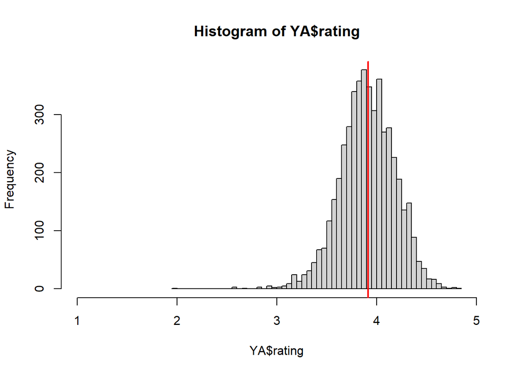

```r
hist(YA$rating, breaks=50, xlim = c(1,5))
abline(v=mean(YA$rating, na.rm = TRUE), col="red", lwd=2)
```

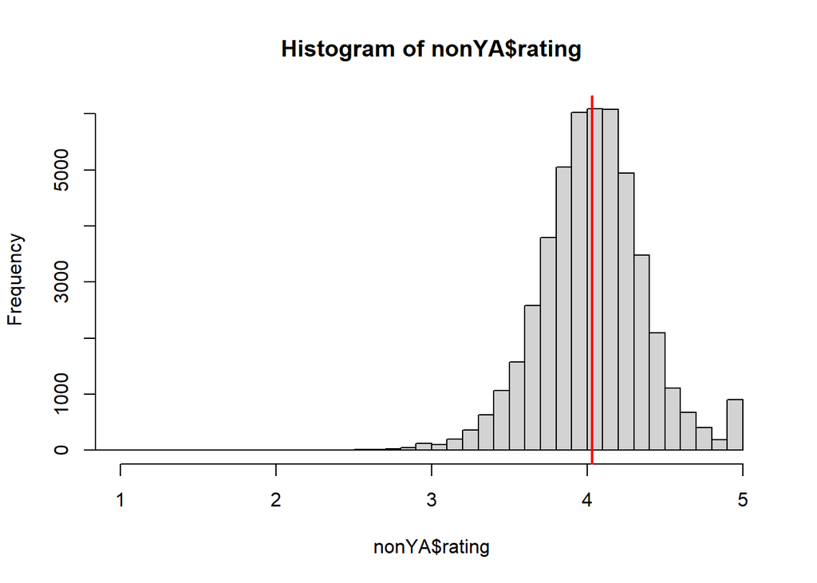

```r
hist(nonYA$rating, breaks=50, xlim = c(1,5))
abline(v=mean(nonYA$rating, na.rm = TRUE), col="red", lwd=2)
```

Prije provedbe T-testa potrebno je usporediti varijance:

```r
var.test(YA$rating, nonYA$rating)
```

```
##
##  F test to compare two variances
##
## data:  YA$rating and nonYA$rating
## F = 0.54026, num df = 4850, denom df = 47626, p-value < 2.2e-16
## alternative hypothesis: true ratio of variances is not equal to 1
## 95 percent confidence interval:
##  0.5183370 0.5635128
## sample estimates:
## ratio of variances
##          0.5402582
```

Varijance ni u ova dva skupa nisu jednake, stoga to moramo navesti pri provedbi testa.

Provedimo T-test:

```r
t.test(YA$rating, nonYA$rating, alternative = "less", var.equal = FALSE)
```

```
##
##  Welch Two Sample t-test
##
## data:  YA$rating and nonYA$rating
## t = -27.794, df = 6826.4, p-value < 2.2e-16
## alternative hypothesis: true difference in means is less than 0
## 95 percent confidence interval:
##        -Inf -0.1123782
## sample estimates:
## mean of x mean of y
##  3.913471  4.032920
```

Test pokazuje da Young Adult knjige imaju značajno manju prosječnu ocjenu

## Usporedba ovisnosti broja stranica i cijene

Čini se sasvim očito pretpostaviti da knjige s više stranica koštaju više od knjiga s manje stranica. Provjerit ćemo postoji li statistički značajna ovisnost tih atributa, ili su te veličine neovisne.

Za početak, podijelit ćemo knjige po broju stranica u dvije skupine, gdje je granica medijan:

```r
goodreads_copy = data.frame(goodreads_dataset)
goodreads_copy = goodreads_copy[!is.na(goodreads_copy$pages),]
goodreads_copy = data.frame(goodreads_copy[!is.na(goodreads_copy$price),])
goodreads_copy_temp = data.frame(goodreads_copy)

median_pages = median(goodreads_copy$pages, na.rm = TRUE)
goodreads_copy$pages[goodreads_copy_temp$pages < median_pages] = "Small"
goodreads_copy$pages[goodreads_copy_temp$pages >= median_pages] = "Big"
tbl = table(goodreads_copy$pages)
tbl
```

```
##
##   Big Small
## 18756 18649
```

Također, podijelit ćemo knjige po cijeni u dvije skupine, gdje je granica također medijan:

```r
median_price = median(goodreads_copy$price, na.rm = TRUE)
goodreads_copy$price[goodreads_copy_temp$price <= median_price] = "Cheap"
goodreads_copy$price[goodreads_copy_temp$price > median_price] = "Expensive"
tbl = table(goodreads_copy$price)
tbl
```

```
##
##     Cheap Expensive
##     18791     18614
```

Napravimo kontingencijsku tablicu:

```r
tbl = table(goodreads_copy$pages, goodreads_copy$price)
tbl_w_margins = addmargins(tbl)
tbl_w_margins
```

```
##
##         Cheap Expensive   Sum
##   Big    9936      8820 18756
##   Small  8855      9794 18649
##   Sum   18791     18614 37405
```

Provedimo hi-kvadrat test neovisnosti:

```r
chisq.test(tbl, correct = F)
```

```
##
##  Pearson's Chi-squared test
##
## data:  tbl
## X-squared = 112.85, df = 1, p-value < 2.2e-16
```

Očito cijena i broj stranica nisu neovisni, ali iz kontingencijske tablice vidimo da je zapravo više velikih knjiga s manjom cijenom i manjih knjiga s velikom cijenom u usporedbi s velikim knjigama s velikom cijenom i malim knjigama s malom cijenom

S obzirom na to da se vrijednosti ovih atributa za većinu primjeraka nalazi vrlo blizu medijana, striktno dijeljenje po medijanu može dovesti do nepreciznih zaključaka, s obzirom na to da se primjerci zbog utjecaja šuma mogu vrlo lako naći na drugoj strani podjele. Stoga bi bilo korisno ispitati podjelu na način da ne dijelimo skup podataka po medijanu, već po nekim drugim kvantilima.

Uzmimo podjelu na tercile:

```r
goodreads_copy = data.frame(goodreads_dataset)
goodreads_copy = goodreads_copy[!is.na(goodreads_copy$pages),]
goodreads_copy = data.frame(goodreads_copy[!is.na(goodreads_copy$price),])
goodreads_copy_temp = data.frame(goodreads_copy)

tertiles_size = quantile(goodreads_copy_temp$pages, probs=c(1/3,2/3), na.rm = TRUE)
goodreads_copy$pages[goodreads_copy_temp$pages < tertiles_size[1]] = "1_Small"
goodreads_copy$pages[goodreads_copy_temp$pages >= tertiles_size[1] & goodreads_copy_temp$pages < tertiles_size[2]] = "2_Medium_size"
goodreads_copy$pages[goodreads_copy_temp$pages >= tertiles_size[2]] = "3_Big"
tbl = table(goodreads_copy$pages)
tbl
```

```
##
##       1_Small 2_Medium_size         3_Big
##         11961         12652         12792
```

```r
tertiles_price = quantile(goodreads_copy_temp$price, probs=c(1/3,2/3), na.rm = TRUE)
goodreads_copy$price[goodreads_copy_temp$price < tertiles_price[1]] = "1_Cheap"
goodreads_copy$price[goodreads_copy_temp$price >= tertiles_price[1] & goodreads_copy_temp$price < tertiles_price[2]] = "2_Medium_price"
goodreads_copy$price[goodreads_copy_temp$price >= tertiles_price[2]] = "3_Expensive"
tbl = table(goodreads_copy$price)
tbl
```

```
##
##        1_Cheap 2_Medium_price    3_Expensive
##          12423          12508          12474
```

```r
tbl = table(goodreads_copy$pages, goodreads_copy$price)
tbl_w_margins = addmargins(tbl)
tbl_w_margins
```

```
##
##                 1_Cheap 2_Medium_price 3_Expensive   Sum
##   1_Small          3518           3644        4799 11961
##   2_Medium_size    4501           4502        3649 12652
##   3_Big            4404           4362        4026 12792
##   Sum             12423          12508       12474 37405
```

```r
chisq.test(tbl, correct = F)
```

```
##
##  Pearson's Chi-squared test
##
## data:  tbl
## X-squared = 384.78, df = 4, p-value < 2.2e-16
```

Čak i u ovakvoj podjeli dobivamo zanemarivo malu P-vrijednost, što ponovno indicira ovisnost cijene o veličini knjige.

## Razlika u popularnosti s obzirom na cijenu

Popularnost ćemo definirati kao ukupan broj ocjena. Podijelimo ponovno skup podataka po cijeni na jeftinije i skuplje te pogledajmo razlikuju li se jeftinije i skuplje knjige po popularnosti:

```r
goodreads_copy = data.frame(goodreads_dataset)
goodreads_copy = goodreads_copy[!is.na(goodreads_copy$price),]
goodreads_copy = data.frame(goodreads_copy[!is.na(goodreads_copy$numRatings),])
goodreads_copy_temp = data.frame(goodreads_copy)

median_price = median(goodreads_copy$price, na.rm = TRUE)
goodreads_copy$price[goodreads_copy_temp$price <= median_price] = "Cheap"
goodreads_copy$price[goodreads_copy_temp$price > median_price] = "Expensive"
tbl = table(goodreads_copy$price)
tbl
```

```
##
##     Cheap Expensive
##     19056     19045
```

Provjerimo kako izgledaju njihove srednje vrijednosti i medijani:

```r
print("Cheap:")
```

```
## [1] "Cheap:"
```

```r
cat("Mean - ", mean(goodreads_copy$numRatings[goodreads_copy$price == "Cheap"]), "\n")
```

```
## Mean -  23942.6
```

```r
cat("Median - ",median(goodreads_copy$numRatings[goodreads_copy$price == "Cheap"]),"\n")
```

```
## Median -  4634
```

```r
print("Expensive:")
```

```
## [1] "Expensive:"
```

```r
cat("Mean - ",mean(goodreads_copy$numRatings[goodreads_copy$price == "Expensive"]),"\n")
```

```
## Mean -  14731.64
```

```r
cat("Median - ",median(goodreads_copy$numRatings[goodreads_copy$price == "Expensive"]),"\n")
```

```
## Median -  2054
```

Naravno, prije testa jednakosti sredina moramo provjeriti varijance obje skupine:

```r
var.test(goodreads_copy$numRatings[goodreads_copy$price == "Cheap"], goodreads_copy$numRatings[goodreads_copy$price == "Expensive"])
```

```
##
##  F test to compare two variances
##
## data:  goodreads_copy$numRatings[goodreads_copy$price == "Cheap"] and goodreads_copy$numRatings[goodreads_copy$price == "Expensive"]
## F = 2.9342, num df = 19055, denom df = 19044, p-value < 2.2e-16
## alternative hypothesis: true ratio of variances is not equal to 1
## 95 percent confidence interval:
##  2.852075 3.018774
## sample estimates:
## ratio of variances
##           2.934241
```

Očito varijance nisu jednake pa moramo to naznačiti pri izvođenju T-testa.

Provedimo prvo standardni T-test:

```r
t.test(goodreads_copy$numRatings[goodreads_copy$price == "Cheap"], goodreads_copy$numRatings[goodreads_copy$price == "Expensive"], alternative = "greater", var.equal = FALSE)
```

```
##
##  Welch Two Sample t-test
##
## data:  goodreads_copy$numRatings[goodreads_copy$price == "Cheap"] and goodreads_copy$numRatings[goodreads_copy$price == "Expensive"]
## t = 9.5023, df = 30695, p-value < 2.2e-16
## alternative hypothesis: true difference in means is greater than 0
## 95 percent confidence interval:
##  7616.494      Inf
## sample estimates:
## mean of x mean of y
##  23942.60  14731.64
```

Zaključujemo da su jeftinije knjige popularnije.

## Predviđanje nagrađivanosti

Zanimljivo bi bilo promotriti može li se nagrađivanost knjige predvidjeti iz ostalih parametara.

Za predviđanje nagrađivanosti koristit ćemo logističku regresiju, s obzirom na to da ćemo nagrađivanost knjige pretvoriti u binarnu varijablu.

Kao regresore upotrijebit ćemo veći broj atributa koji bi mogli donijeti informaciju o nagrađivanosti, a nakon procjene parametara logističke regresije vidjet ćemo koji od atributa su najkorisniji za predviđanje.

Atribute koji su kategoričke varijable prije procjene parametara logističke regresije treba pretvoriti u faktore, a potrebno je izbaciti i nedostajuće vrijednosti.

```r
library(dplyr)
goodreads_copy = select(data.frame(goodreads_dataset),awards,rating,language,genre1,genre2,pages,numRatings,price,likedPercent)
goodreads_copy = goodreads_copy[complete.cases(goodreads_copy),]
print(length(goodreads_copy$awards))
```

```
## [1] 35443
```

```r
goodreads_copy$language = factor(goodreads_copy$language)
goodreads_copy$genre1 = factor(goodreads_copy$genre1)
goodreads_copy$genre2 = factor(goodreads_copy$genre2)
```

Sada možemo raditi logističku regresiju:

```r
logreg.mdl = glm(awards ~ rating + language + genre1 + genre2 + pages + numRatings + price + likedPercent, data=goodreads_copy, family = binomial())
summary(logreg.mdl)
```

```
##
## Call:
## glm(formula = awards ~ rating + language + genre1 + genre2 +
##     pages + numRatings + price + likedPercent, family = binomial(),
##     data = goodreads_copy)
##
## Deviance Residuals:
##     Min       1Q   Median       3Q      Max
## -6.2826  -0.7987  -0.6436   0.2290   2.6732
##
## Coefficients:
##                                       Estimate Std. Error z value Pr(>|z|)
## (Intercept)                         -1.299e+01  5.354e+02  -0.024 0.980649
## rating                              -4.253e-01  9.754e-02  -4.360 1.30e-05 ***
## languageAleut                       -9.208e-01  7.572e+02  -0.001 0.999030
## languageAmharic                     -4.055e-01  7.572e+02  -0.001 0.999573
## languageArabic                       1.135e+01  5.354e+02   0.021 0.983089
## languageBasque                      -6.740e-01  7.572e+02  -0.001 0.999290
## languageBengali                     -6.216e-01  5.561e+02  -0.001 0.999108
## languageBulgarian                    1.150e+01  5.354e+02   0.021 0.982856
## languageCatalan; Valencian           1.332e+01  5.354e+02   0.025 0.980158
## languageChinese                     -2.683e-01  6.110e+02   0.000 0.999650
## languageCroatian                    -6.279e-01  7.572e+02  -0.001 0.999338
## languageCzech                        1.255e+01  5.354e+02   0.023 0.981302
## languageDanish                       1.200e+01  5.354e+02   0.022 0.982116
## languageDuala                       -9.756e-01  7.572e+02  -0.001 0.998972
## languageDutch                        1.249e+01  5.354e+02   0.023 0.981381
## languageEnglish                      1.170e+01  5.354e+02   0.022 0.982567
## languageEnglish, Middle (1100-1500) -2.948e-01  7.572e+02   0.000 0.999689
## languageEstonian                     1.317e+01  5.354e+02   0.025 0.980373
## languageFaroese                     -1.208e+00  7.572e+02  -0.002 0.998727
## languageFilipino; Pilipino           1.274e+01  5.354e+02   0.024 0.981011
## languageFinnish                      1.327e+01  5.354e+02   0.025 0.980232
## languageFrench                       1.161e+01  5.354e+02   0.022 0.982707
## languageGalician                     1.169e+00  7.572e+02   0.002 0.998768
## languageGeorgian                     1.193e+01  5.354e+02   0.022 0.982223
## languageGerman                       1.155e+01  5.354e+02   0.022 0.982787
## languageGreek, Ancient (to 1453)    -1.276e-01  7.572e+02   0.000 0.999866
## languageGreek, Modern (1453-)        1.237e+01  5.354e+02   0.023 0.981564
## languageHindi                        4.871e-02  6.181e+02   0.000 0.999937
```

[output cut: 43 more lines]

```
## genre2Young Adult                    1.296e-01  1.276e-01   1.016 0.309553
## pages                                1.589e-04  5.634e-05   2.821 0.004787 **
## numRatings                           9.533e-06  3.456e-07  27.585  < 2e-16 ***
## price                               -3.142e-03  8.574e-04  -3.665 0.000247 ***
## likedPercent                         2.113e-02  5.313e-03   3.977 6.97e-05 ***
## ---
## Signif. codes:  0 '***' 0.001 '**' 0.01 '*' 0.05 '.' 0.1 ' ' 1
##
## (Dispersion parameter for binomial family taken to be 1)
##
##     Null deviance: 40135  on 35442  degrees of freedom
## Residual deviance: 36688  on 35367  degrees of freedom
## AIC: 36840
##
## Number of Fisher Scoring iterations: 12
```

Vidimo zanimljive interpretacije rezultata:

- Niti jedan jezik statistički značajno ne indicira dobivanje nagrade.
- Ocjena (rating) značajno predviđa dobivanje nagrade i ta korelacija je negativna - veća ocjena daje manju vjerojatnost dobivanja nagrade
- Također značajno, ali suprotno prethodnome, postotak sviđanja (likedPercent) ima pozitivnu korelaciju s dobivanjem nagrade
- Cijena značajno predviđa nagrađivanost, i negativno su korelirani
- S obzirom na žanrove, značajni pozitivni indikatori su ratne i povijesne knjige te memoari, dok su značajni negativni indikatori religija, romansa, triler, klasik i općenito publicistika
- Broj stranica i broj ocjena značajno su pozitivno korelirani s dobivanjem nagrada

```r
Rsq = 1 - logreg.mdl$deviance/logreg.mdl$null.deviance
Rsq
```

```
## [1] 0.08586972
```

```r
yHat <- logreg.mdl$fitted.values >= 0.5

tab <- table(goodreads_copy$awards, yHat)

tab
```

```
##    yHat
##     FALSE  TRUE
##   0 26153   304
##   1  8167   819
```

```r
accuracy = sum(diag(tab)) / sum(tab)
precision = tab[2,2] / sum(tab[,2])
recall = tab[2,2] / sum(tab[2,])
specificity = tab[1,1] / sum(tab[,1])

accuracy
```

```
## [1] 0.7609965
```

```r
precision
```

```
## [1] 0.7292965
```

```r
recall
```

```
## [1] 0.09114178
```

```r
specificity
```

```
## [1] 0.7620338
```

Provedimo procjenu parametara ponovno, ali ovaj put bez jezika, koji se nije pokazao kao statistički zanačajan:

```r
logreg.mdl = glm(awards ~ rating + genre1 + genre2 + pages + numRatings + price + likedPercent, data=goodreads_copy, family = binomial())
summary(logreg.mdl)
```

```
##
## Call:
## glm(formula = awards ~ rating + genre1 + genre2 + pages + numRatings +
##     price + likedPercent, family = binomial(), data = goodreads_copy)
##
## Deviance Residuals:
##     Min       1Q   Median       3Q      Max
## -6.2935  -0.7980  -0.6444   0.2294   2.6772
##
## Coefficients:
##                            Estimate Std. Error z value Pr(>|z|)
## (Intercept)              -1.240e+00  2.803e-01  -4.423 9.74e-06 ***
## rating                   -4.596e-01  9.699e-02  -4.738 2.15e-06 ***
## genre1Nonfiction         -5.945e-01  6.181e-02  -9.619  < 2e-16 ***
## genre1Other              -1.849e+00  1.049e-01 -17.619  < 2e-16 ***
## genre1Poetry              9.414e-02  1.006e-01   0.936 0.349401
## genre2Classics           -8.297e-01  1.325e-01  -6.264 3.76e-10 ***
## genre2Crime               1.602e-01  1.397e-01   1.147 0.251523
## genre2Drama              -1.131e-01  1.795e-01  -0.630 0.528664
## genre2Fantasy            -1.341e-01  1.257e-01  -1.067 0.285792
## genre2Historical          7.760e-01  1.652e-01   4.697 2.65e-06 ***
## genre2Historical Fiction  3.228e-01  1.273e-01   2.535 0.011230 *
## genre2Horror             -8.825e-02  1.431e-01  -0.617 0.537443
## genre2Memoir              4.535e-01  1.424e-01   3.184 0.001451 **
## genre2Other              -2.115e-01  1.299e-01  -1.628 0.103472
## genre2Religion           -6.337e-01  1.606e-01  -3.946 7.95e-05 ***
## genre2Romance            -5.058e-01  1.290e-01  -3.922 8.79e-05 ***
## genre2Science Fiction     1.213e-01  1.333e-01   0.910 0.363022
## genre2Short Stories      -2.193e-02  1.500e-01  -0.146 0.883736
## genre2Thriller           -3.329e-01  1.385e-01  -2.404 0.016203 *
## genre2War                 8.672e-01  1.645e-01   5.273 1.34e-07 ***
## genre2Young Adult         1.253e-01  1.273e-01   0.984 0.324921
## pages                     1.609e-04  5.608e-05   2.870 0.004106 **
## numRatings                9.563e-06  3.449e-07  27.730  < 2e-16 ***
## price                    -2.962e-03  8.266e-04  -3.583 0.000339 ***
## likedPercent              2.211e-02  5.292e-03   4.178 2.94e-05 ***
## ---
## Signif. codes:  0 '***' 0.001 '**' 0.01 '*' 0.05 '.' 0.1 ' ' 1
##
## (Dispersion parameter for binomial family taken to be 1)
##
##     Null deviance: 40135  on 35442  degrees of freedom
## Residual deviance: 36797  on 35418  degrees of freedom
## AIC: 36847
##
## Number of Fisher Scoring iterations: 6
```

```r
Rsq = 1 - logreg.mdl$deviance/logreg.mdl$null.deviance
Rsq
```

```
## [1] 0.08315821
```

```r
yHat <- logreg.mdl$fitted.values >= 0.5

tab <- table(goodreads_copy$awards, yHat)

tab
```

```
##    yHat
##     FALSE  TRUE
##   0 26180   277
##   1  8208   778
```

## Predviđanje ocjene knjige

Linearnom regresijom nastojimo pokazati vezu između regresora (nezavnisnih varijabli) i rekacije (zavisne varijable). U ovom dijelu pokušat ćemo predvidjeti ocjenu knjige na temelju dostupnih varijabli. Prvo moramo vizualizirati ocjene knjiga u ovisnosti o nekim odabranim varijablama. Uzimamo broj ocjena (popularnost knjige), likedPercent, broj stranica i cijenu te gledamo kako utječu na ocjenu knjige.

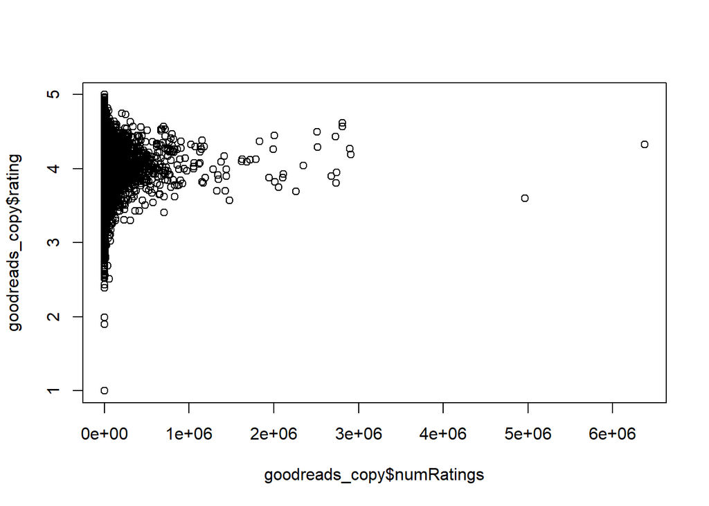

```r
plot(goodreads_copy$numRatings, goodreads_copy$rating)
```

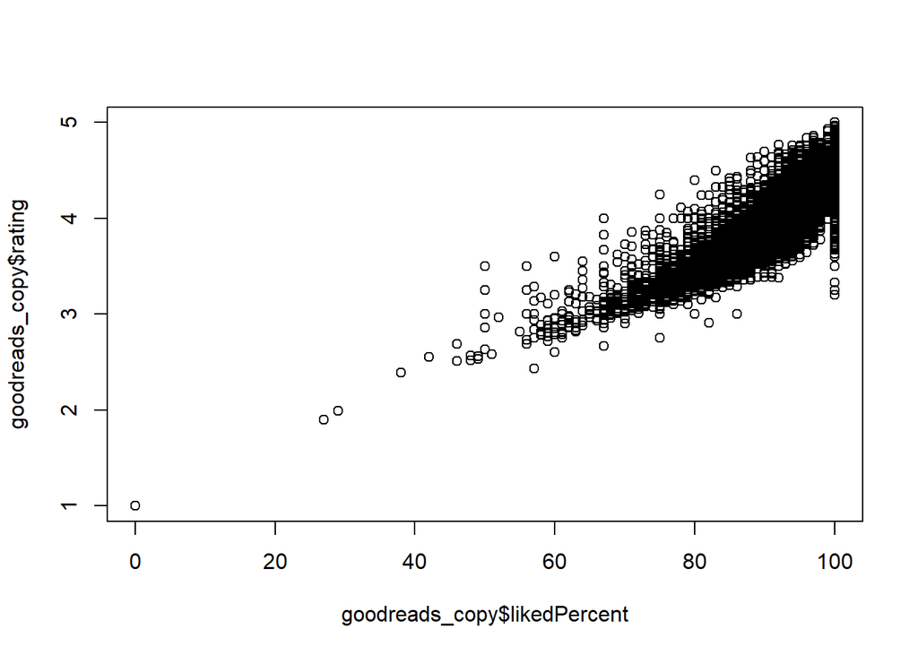

```r
plot(goodreads_copy$likedPercent, goodreads_copy$rating)
```

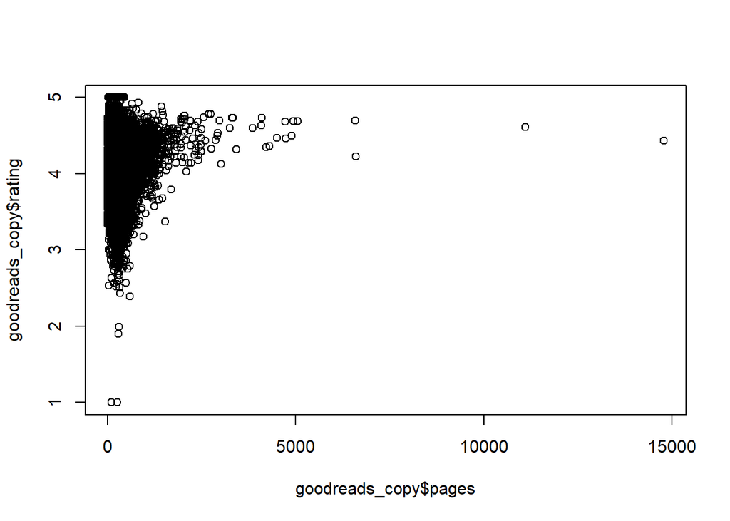

```r
plot(goodreads_copy$pages, goodreads_copy$rating)
```

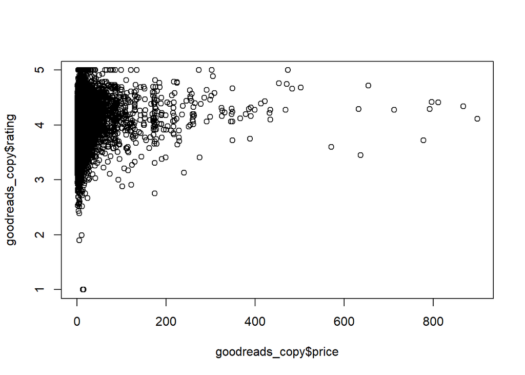

```r
plot(goodreads_copy$price, goodreads_copy$rating)
```

Od svih odabranih varijabli, likedPercent ima vizualno linearnu vezu s ocjenom knjige (što je veći likedPercent, to je veća ocjena knjige), što bi se i intuitivno dalo pretpostaviti. Provodimo linearnu regresiju s likedPercent kao regresorom.

```r
fit.likedPercent = lm(rating~likedPercent, data = goodreads_copy)
summary(fit.likedPercent)
```

```
##
## Call:
## lm(formula = rating ~ likedPercent, data = goodreads_copy)
##
## Residuals:
##      Min       1Q   Median       3Q      Max
## -1.14885 -0.10612 -0.01612  0.08609  1.45636
##
## Coefficients:
##               Estimate Std. Error t value Pr(>|t|)
## (Intercept)  -0.261572   0.014978  -17.46   <2e-16 ***
## likedPercent  0.046104   0.000162  284.51   <2e-16 ***
## ---
## Signif. codes:  0 '***' 0.001 '**' 0.01 '*' 0.05 '.' 0.1 ' ' 1
##
## Residual standard error: 0.1616 on 35441 degrees of freedom
## Multiple R-squared:  0.6955, Adjusted R-squared:  0.6955
## F-statistic: 8.095e+04 on 1 and 35441 DF,  p-value: < 2.2e-16
```

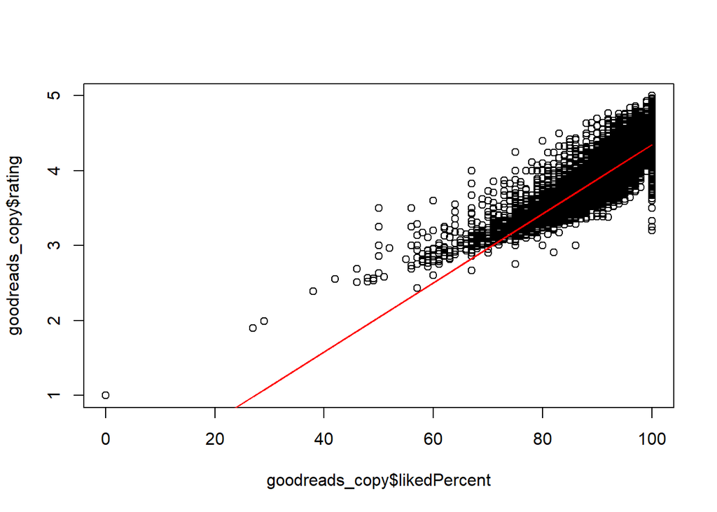

```r
plot(goodreads_copy$likedPercent, goodreads_copy$rating)
lines(goodreads_copy$likedPercent, fit.likedPercent$fitted, col='red')
```

Sudeći po koeficijentu determinacije, model opisuje čvrstu linearnu vezu između ocjene i postotka, na što ukazuje i graf, no trebamo još provesti analizu reziduala.

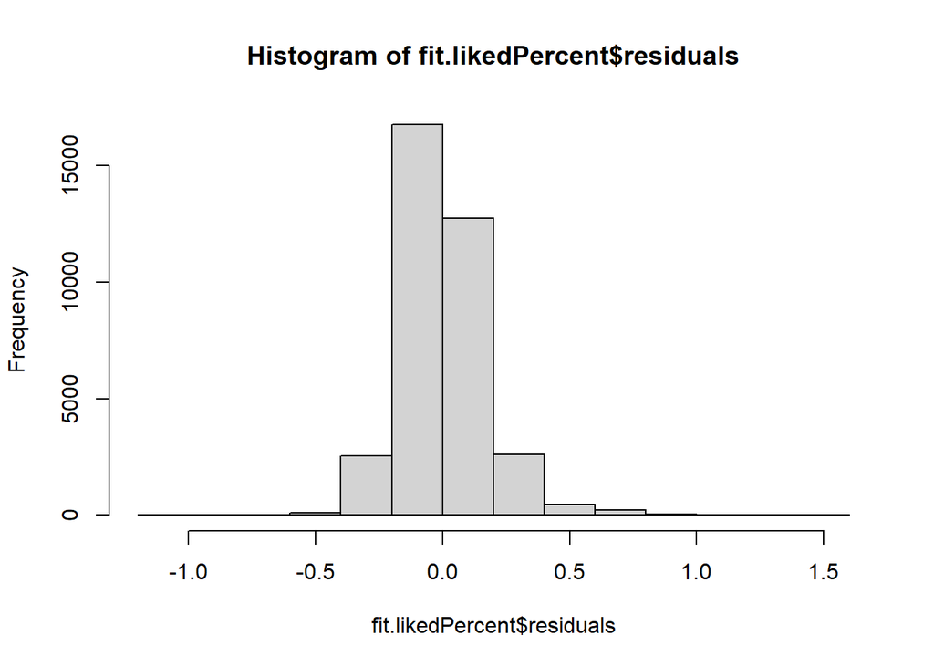

```r
hist(fit.likedPercent$residuals)
```

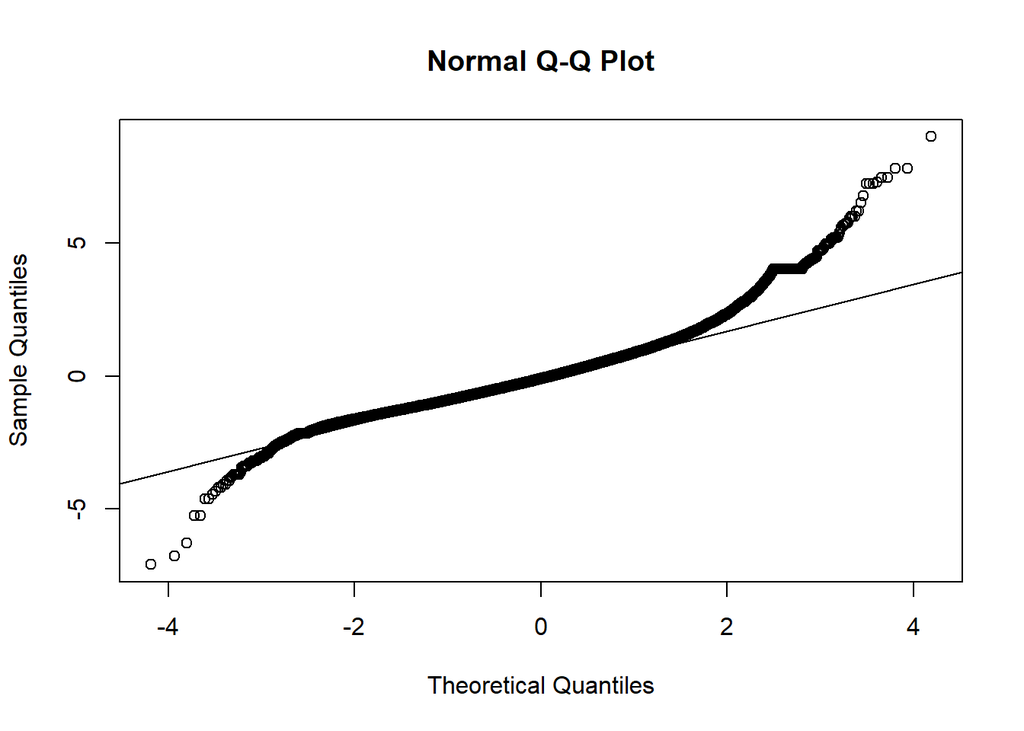

```r
qqnorm(rstandard(fit.likedPercent))
qqline(rstandard(fit.likedPercent))
```

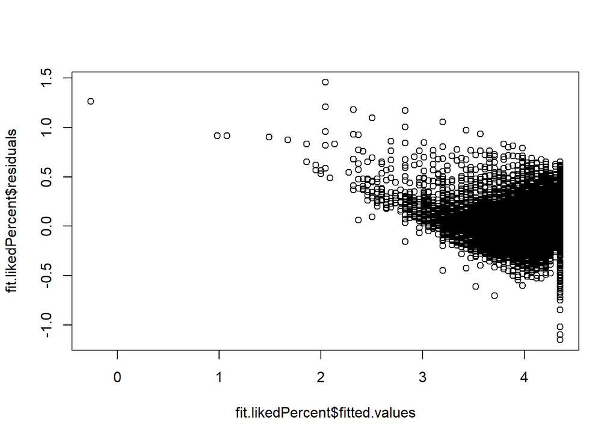

```r
plot(fit.likedPercent$fitted.values, fit.likedPercent$residuals)
```

Q-Q plot pokazuje da distribucija reziduala u repovima odstupa od normalne, ali provesti ćemo još i Lillieforsov test normalnosti.

```r
library(nortest)
lillie.test(rstandard(fit.likedPercent))
```

```
##
##  Lilliefors (Kolmogorov-Smirnov) normality test
##
## data:  rstandard(fit.likedPercent)
## D = 0.051812, p-value < 2.2e-16
```

Test potvrđuje da nam reziduali nisu normalno distribuirani, što znači da su pretpostavke linearne regresije značajno narušene.

Svejedno, probajmo koristiti kvadratnu funkciju umjesto pravca s likedPercent da vidimo možemo li poboljšati rezultat.

```r
#
fit.likedPercent.sq = lm(rating ~ likedPercent + I(likedPercent^2),data = goodreads_copy)
summary(fit.likedPercent.sq)
```

```
##
## Call:
## lm(formula = rating ~ likedPercent + I(likedPercent^2), data = goodreads_copy)
##
## Residuals:
##      Min       1Q   Median       3Q      Max
## -2.84550 -0.09744 -0.01159  0.08202  1.01943
##
## Coefficients:
##                     Estimate Std. Error t value Pr(>|t|)
## (Intercept)        3.845e+00  6.932e-02   55.48   <2e-16 ***
## likedPercent      -4.998e-02  1.595e-03  -31.35   <2e-16 ***
## I(likedPercent^2)  5.571e-04  9.202e-06   60.55   <2e-16 ***
## ---
## Signif. codes:  0 '***' 0.001 '**' 0.01 '*' 0.05 '.' 0.1 ' ' 1
##
## Residual standard error: 0.1539 on 35440 degrees of freedom
## Multiple R-squared:  0.724,  Adjusted R-squared:  0.724
## F-statistic: 4.649e+04 on 2 and 35440 DF,  p-value: < 2.2e-16
```

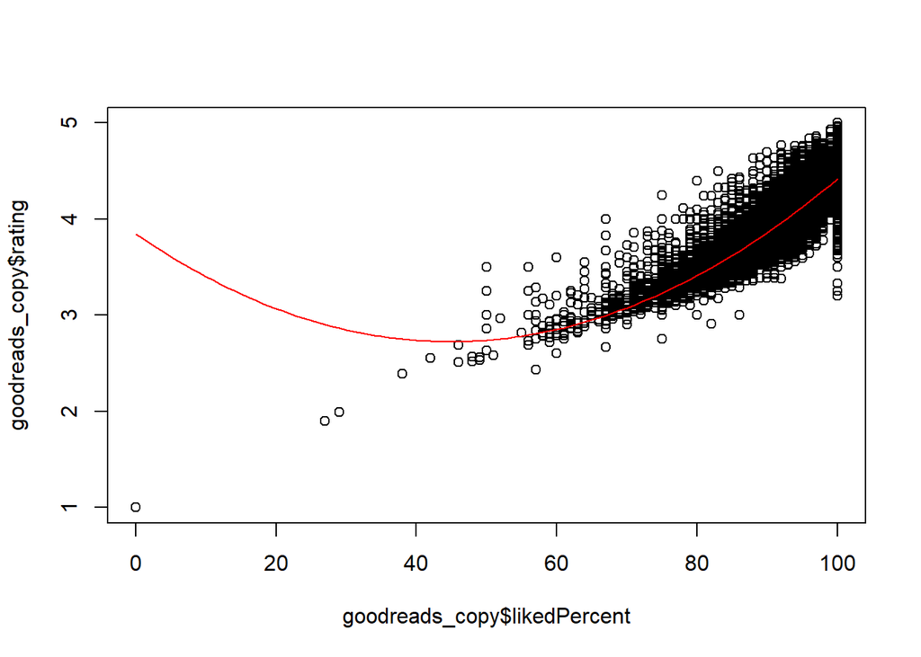

```r
#jednostavan nacin za graficki prikazati nelinearne krivulje
f = function(x, coeffs)
  return(coeffs[[1]] + coeffs[[2]] * x + coeffs[[3]] * x^2)
plot(goodreads_copy$likedPercent,goodreads_copy$rating)
curve(f(x, fit.likedPercent.sq$coefficients), add = TRUE, col = "red")
```

Vidimo da nam je vrijednost R^2 poboljšana u odnosu na kada smo koristili pravac i sada je obuhvaćeno više varijance.

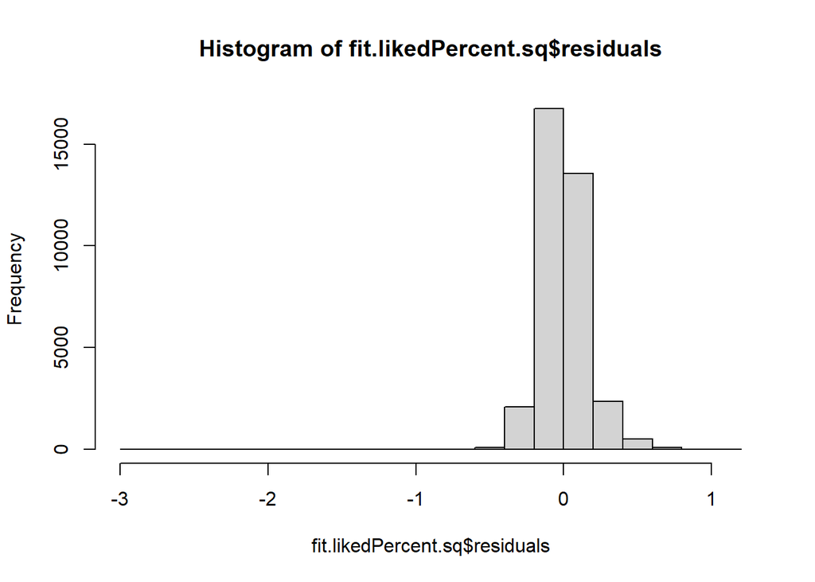

```r
hist(fit.likedPercent.sq$residuals)
```

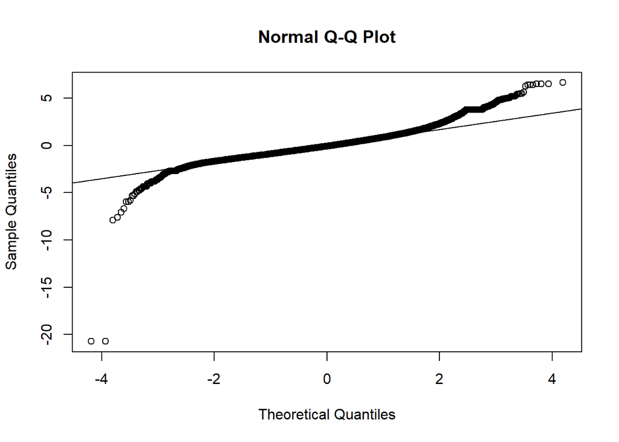

```r
qqnorm(rstandard(fit.likedPercent.sq))
qqline(rstandard(fit.likedPercent.sq))
```

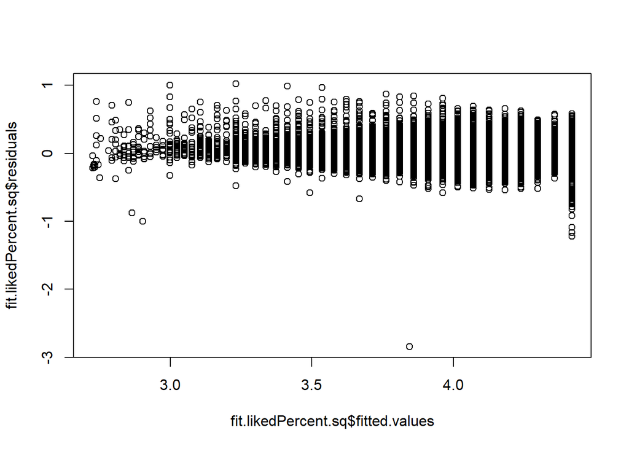

```r
plot(fit.likedPercent.sq$fitted.values, fit.likedPercent.sq$residuals)
```

I u ovom slučaju vidimo u Q-Q plotu da repovi odstupaju od normalne distribucije. Međutim, reziduali izgledaju puno bolje (nasumičnije) nego kada smo koristili pravac.

```r
lillie.test(rstandard(fit.likedPercent.sq))
```

```
##
##  Lilliefors (Kolmogorov-Smirnov) normality test
##
## data:  rstandard(fit.likedPercent.sq)
## D = 0.050414, p-value < 2.2e-16
```

Lilliefors test potvrđuje da nam ni ovdje reziduali nisu normalno distribuirani.

## Ovisnost cijene o jeziku i broju stranica

Osim ocjene, možemo provjeriti možemo li predvidjeti cijenu knjige na temelju regresora kao što su jezik, broj stranica, žanr.

```r
fit = lm(price ~ language + pages + genre1 + genre2, data = goodreads_copy)
summary(fit)
```

```
##
## Call:
## lm(formula = price ~ language + pages + genre1 + genre2, data = goodreads_copy)
##
## Residuals:
##    Min     1Q Median     3Q    Max
## -97.24  -5.41  -2.58   0.51 891.30
##
## Coefficients:
##                                       Estimate Std. Error t value Pr(>|t|)
## (Intercept)                          1.023e+01  2.305e+01   0.444  0.65721
## languageAleut                       -1.461e+01  3.255e+01  -0.449  0.65349
## languageAmharic                      3.703e+00  3.254e+01   0.114  0.90941
## languageArabic                      -1.977e+00  2.317e+01  -0.085  0.93201
## languageBasque                       5.698e+00  3.254e+01   0.175  0.86100
## languageBengali                      1.862e+00  2.395e+01   0.078  0.93804
## languageBulgarian                   -7.989e+00  2.486e+01  -0.321  0.74790
## languageCatalan; Valencian           1.151e+01  2.414e+01   0.477  0.63355
## languageChinese                     -2.302e+00  2.657e+01  -0.087  0.93097
## languageCroatian                    -9.409e+00  3.254e+01  -0.289  0.77249
## languageCzech                        9.523e+00  2.521e+01   0.378  0.70559
## languageDanish                       1.027e+01  2.460e+01   0.417  0.67636
## languageDuala                       -1.541e+01  3.255e+01  -0.474  0.63585
## languageDutch                       -3.935e+00  2.313e+01  -0.170  0.86489
## languageEnglish                     -7.997e+00  2.301e+01  -0.348  0.72822
## languageEnglish, Middle (1100-1500) -1.512e+01  3.256e+01  -0.464  0.64239
## languageEstonian                     4.343e-01  2.521e+01   0.017  0.98626
## languageFaroese                     -9.604e+00  3.254e+01  -0.295  0.76791
## languageFilipino; Pilipino           6.647e+01  2.460e+01   2.702  0.00690 **
## languageFinnish                      1.500e+01  2.404e+01   0.624  0.53262
## languageFrench                      -9.487e+00  2.304e+01  -0.412  0.68045
## languageGalician                    -1.989e+01  3.254e+01  -0.611  0.54108
## languageGeorgian                     3.976e+01  2.573e+01   1.545  0.12229
## languageGerman                      -1.156e+01  2.304e+01  -0.502  0.61582
## languageGreek, Ancient (to 1453)    -1.181e+01  3.255e+01  -0.363  0.71663
## languageGreek, Modern (1453-)        1.942e+01  2.361e+01   0.822  0.41088
## languageHindi                        6.835e+00  2.658e+01   0.257  0.79705
## languageHungarian                    5.401e+01  2.818e+01   1.916  0.05532 .
## languageIndonesian                   7.627e+00  2.341e+01   0.326  0.74453
## languageItalian                     -2.660e+00  2.308e+01  -0.115  0.90826
```

[output cut: 33 more lines]

```
## genre2Memoir                         1.930e+00  1.378e+00   1.401  0.16132
## genre2Other                          5.164e+00  1.252e+00   4.123 3.74e-05 ***
## genre2Religion                       2.197e+00  1.417e+00   1.551  0.12100
## genre2Romance                       -9.102e-01  1.257e+00  -0.724  0.46902
## genre2Science Fiction                3.449e+00  1.332e+00   2.589  0.00962 **
## genre2Short Stories                  5.209e+00  1.487e+00   3.504  0.00046 ***
## genre2Thriller                      -2.505e+00  1.361e+00  -1.840  0.06573 .
## genre2War                            1.753e+00  1.678e+00   1.045  0.29607
## genre2Young Adult                   -1.007e+00  1.259e+00  -0.800  0.42369
## ---
## Signif. codes:  0 '***' 0.001 '**' 0.01 '*' 0.05 '.' 0.1 ' ' 1
##
## Residual standard error: 23.01 on 35371 degrees of freedom
## Multiple R-squared:  0.06071,    Adjusted R-squared:  0.05882
## F-statistic:  32.2 on 71 and 35371 DF,  p-value: < 2.2e-16
```

Možemo uočiti sljedeće:

- Niti jedan jezik statistički značajno ne indicira višu cijenu, osim Filipinskog.
- Broj stranica se čini kao pozitivno koreliran s cijenom.
- Među žanrovima neki od njih su pozitvno korelirani s cijenom: poezija, horor, SF i kratke priče. Kada pogledamo koeficijent determinacije vidimo da je riječ o slaboj linearnoj ovisnosti, dok F-statistika ukazuje da je test značajan.

Kako se jezik nije pokazao kao značajan prediktor, možemo samo provesti jednostavnu regresiju koristeći broj stranica kao prediktor, te dobivenu vezu možemo prikazati grafički:

```r
fit = lm(price ~ pages, data = goodreads_copy)
summary(fit)
```

```
##
## Call:
## lm(formula = price ~ pages, data = goodreads_copy)
##
## Residuals:
##    Min     1Q Median     3Q    Max
## -76.91  -6.05  -4.05  -0.37 890.50
##
## Coefficients:
##              Estimate Std. Error t value Pr(>|t|)
## (Intercept) 5.4597721  0.2208523   24.72   <2e-16 ***
## pages       0.0112585  0.0005349   21.05   <2e-16 ***
## ---
## Signif. codes:  0 '***' 0.001 '**' 0.01 '*' 0.05 '.' 0.1 ' ' 1
##
## Residual standard error: 23.57 on 35441 degrees of freedom
## Multiple R-squared:  0.01234,    Adjusted R-squared:  0.01232
## F-statistic:   443 on 1 and 35441 DF,  p-value: < 2.2e-16
```

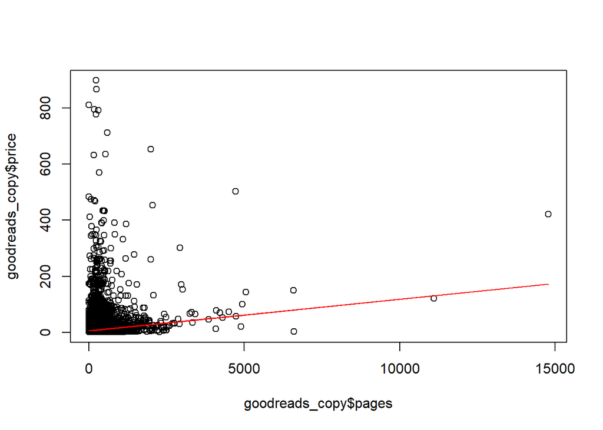

```r
plot(goodreads_copy$pages, goodreads_copy$price)
lines(goodreads_copy$pages, fit$fitted.values, col='red')
```

```r
fit = lm(price ~ pages + genre1 + genre2, data = goodreads_copy)
summary(fit)
```

```
##
## Call:
## lm(formula = price ~ pages + genre1 + genre2, data = goodreads_copy)
##
## Residuals:
##    Min     1Q Median     3Q    Max
## -88.33  -5.77  -3.00   0.19 891.03
##
## Coefficients:
##                            Estimate Std. Error t value Pr(>|t|)
## (Intercept)               2.7252104  1.2261760   2.223  0.02625 *
## pages                     0.0130764  0.0005395  24.239  < 2e-16 ***
## genre1Nonfiction         -0.2174783  0.5290108  -0.411  0.68100
## genre1Other               7.2917496  0.5696120  12.801  < 2e-16 ***
## genre1Poetry              4.3447530  0.9255469   4.694 2.69e-06 ***
## genre2Classics            2.1650277  1.2856825   1.684  0.09220 .
## genre2Crime              -0.1687685  1.4175174  -0.119  0.90523
## genre2Drama               3.4929928  1.7806251   1.962  0.04981 *
## genre2Fantasy             1.8276426  1.2562544   1.455  0.14572
## genre2Historical          1.3825729  1.6950223   0.816  0.41470
## genre2Historical Fiction -1.1540312  1.2835951  -0.899  0.36863
## genre2Horror              4.3582261  1.4329589   3.041  0.00236 **
## genre2Memoir              1.9857282  1.3944227   1.424  0.15444
## genre2Other               5.3842106  1.2666237   4.251 2.14e-05 ***
## genre2Religion            2.3240725  1.4333513   1.621  0.10494
## genre2Romance            -0.5980475  1.2719185  -0.470  0.63822
## genre2Science Fiction     3.0229131  1.3482738   2.242  0.02496 *
## genre2Short Stories       6.4008562  1.5037675   4.257 2.08e-05 ***
## genre2Thriller           -2.6797055  1.3769795  -1.946  0.05165 .
## genre2War                 1.6629652  1.6984780   0.979  0.32754
## genre2Young Adult        -1.4586858  1.2737496  -1.145  0.25214
## ---
## Signif. codes:  0 '***' 0.001 '**' 0.01 '*' 0.05 '.' 0.1 ' ' 1
##
## Residual standard error: 23.31 on 35422 degrees of freedom
## Multiple R-squared:  0.0347, Adjusted R-squared:  0.03415
## F-statistic: 63.66 on 20 and 35422 DF,  p-value: < 2.2e-16
```

Na temelju dobivenih vrijednosti vidimo da ni žanr u kombinaciji s brojem stranica nije dobar prediktor.

## Analiza varijance i neparametarski testovi

Želimo li usporediti sredine i medijane broja ljudi koji su dodijelili svaku od 5 mogućih ocjena knjigama, u svrhu provjeravanja dali korisnici stvarno ocjenjuju knjige uniformno, ne možemo koristiti iste testove za usporedbu kao ranije. S obzirom da sada imamo 5 uzoraka, po jedan za svaku od 5 mogućih ocjena, mogli bismo napraviti višestruko testiranje većim brojem T-testova. Međutim, to nije dobar pristup, jer nam se ovisno o odabranoj razini značajnosti povećava kumulativna vjerojatnost pogreške prvog tipa.

ANOVA metoda omogućava nam istodobno testiranje hipoteza postoji li značajno odstupanje među sredinama svih 5 uzoraka pomoću dekompozicije varijabilnosti na varijabilnost sredina uzoraka među kumulativnom sredinom i na varijabilnost unutar uzoračkih grupa prema vlastitoj sredini.

```r
df <- read.csv("Goodreads-dataset-sanitized-arr.csv", header = TRUE, sep=",")
head(df)
```

```
##   Column1             title            series                            author
## 1       0 Attracted to Fire                      DiAnn Mills (Goodreads Author)
## 2       1         Elemental Soul Guardians #2 Kim Richardson (Goodreads Author)
## 3       2      Unbelievable      Port Fare #2  Sherry Gammon (Goodreads Author)
## 4       3         Fractured        Fateful #2  Cheri Schmidt (Goodreads Author)
## 5       4           Anasazi Sense of Truth #2                     Emma Michaels
## 6       5            Marked Soul Guardians #1 Kim Richardson (Goodreads Author)
##   rating language
## 1   4.14  English
## 2   4.07  English
## 3   4.16  English
## 4   4.00  English
## 5   4.19  English
## 6   3.70  English
##                                                                                                                                                          genres
```

[output cut: 20 more lines]

Prvo pretprocesiramo podatke s ciljem izdvajanja pojedinačnih brojeva ocjena zvjezdicama.

```r
library(stringr)
library(purrr)
x = nrow(df)
for(i in 1:x){
  ratings = str_split_fixed(gsub("\\[|'|\\]|,"," ",df$ratingsByStars[i]), "\\s+",6)[2:6]
  ratings[5] = str_trim(ratings[5])
  ratings = ratings %>%
    map_int(function(x) strtoi(x))

  df$X1.star[i] = ratings[1]
  df$X2.star[i] = ratings[2]
  df$X3.star[i] = ratings[3]
  df$X4.star[i] = ratings[4]
  df$X5.star[i] = ratings[5]
}
write.csv(df,file="Goodreads-dataset-sanitized-second.csv",na = "")
head(df)
```

```
##   Column1             title            series                            author
## 1       0 Attracted to Fire                      DiAnn Mills (Goodreads Author)
## 2       1         Elemental Soul Guardians #2 Kim Richardson (Goodreads Author)
## 3       2      Unbelievable      Port Fare #2  Sherry Gammon (Goodreads Author)
## 4       3         Fractured        Fateful #2  Cheri Schmidt (Goodreads Author)
## 5       4           Anasazi Sense of Truth #2                     Emma Michaels
## 6       5            Marked Soul Guardians #1 Kim Richardson (Goodreads Author)
##   rating language
## 1   4.14  English
## 2   4.07  English
## 3   4.16  English
## 4   4.00  English
## 5   4.19  English
## 6   3.70  English
##                                                                                                                                                          genres
```

[output cut: 27 more lines]

Stupci X5.star,X4.star,…,X1.star prikazuju broj ljudi koji su knjizi dodijelili ocjenu 5,4,…,1. Kako bismo mogli analizirati ANOVA postupak, potrebno je provjeriti jesu li zadovoljene ANOVA pretpostavke homoskedastičnosti, normalnosti i nezavisnosti tih 5 populacija.

Najprije prikazujemo broj korisnika koji je nekoj knjizi dodijelio određenu ocjenu kao postotak, s obzirom da sve knjige nisu jednako ocjenjivane.

```r
x = nrow(df)
for(i in 1:x){
  sum_retka = df$X1.star[i]+df$X2.star[i]+df$X3.star[i]+df$X4.star[i]+df$X5.star[i]
  df$X1.star[i] = df$X1.star[i]/sum_retka
  df$X2.star[i] = df$X2.star[i]/sum_retka
  df$X3.star[i] = df$X3.star[i]/sum_retka
  df$X4.star[i] = df$X4.star[i]/sum_retka
  df$X5.star[i] = df$X5.star[i]/sum_retka
}
head(df)
```

```
##   Column1             title            series                            author
## 1       0 Attracted to Fire                      DiAnn Mills (Goodreads Author)
## 2       1         Elemental Soul Guardians #2 Kim Richardson (Goodreads Author)
## 3       2      Unbelievable      Port Fare #2  Sherry Gammon (Goodreads Author)
## 4       3         Fractured        Fateful #2  Cheri Schmidt (Goodreads Author)
## 5       4           Anasazi Sense of Truth #2                     Emma Michaels
## 6       5            Marked Soul Guardians #1 Kim Richardson (Goodreads Author)
##   rating language
## 1   4.14  English
## 2   4.07  English
## 3   4.16  English
## 4   4.00  English
## 5   4.19  English
## 6   3.70  English
##                                                                                                                                                          genres
```

[output cut: 27 more lines]

Najprije provjeravamo normalnost uzorka, što je ključno za pretpostavke ANOVA-e. Normalnost možemo provjeriti: 1) vizualno - što je dobro kada želimo samo naslutiti kakvog je distribucija oblika -Q-Q plotom -histogramom

2. konkretnim testovima -Kolgomorov-Smirnovljevim testom -Liliforsovom inačicom Kolgomorov-Smirnovljevog testa

Iz prikazanih histograma i Q-Q plotova vidimo kako je distribucija za neke ocjene aproksimativno normalna, ali za neke i jako zakrivljena. Treći moment tih distribucija izrazito je velik. Iako je ANOVA postupak relativno robustan na normalnost, ovdje ju nećemo koristiti iz opravdanih razloga. Bolji izbor je Kruskal-Wallisov test

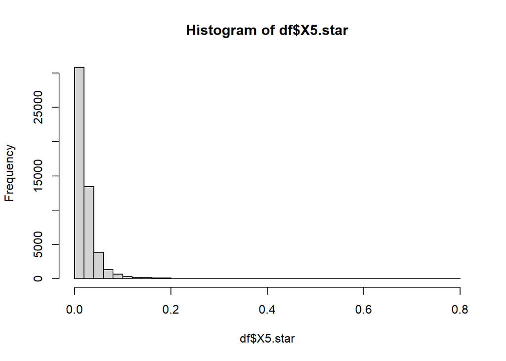

```r
hist(df$X5.star, breaks=50)
```

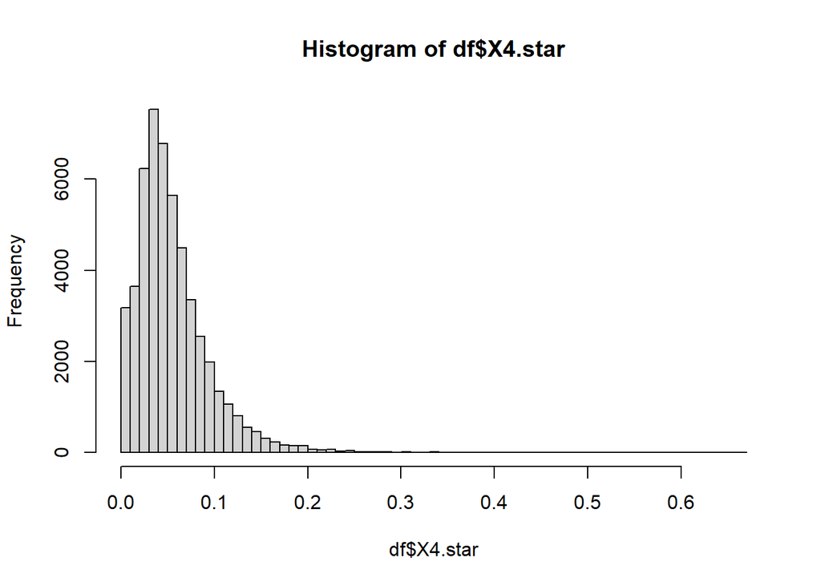

```r
hist(df$X4.star, breaks=50)
```

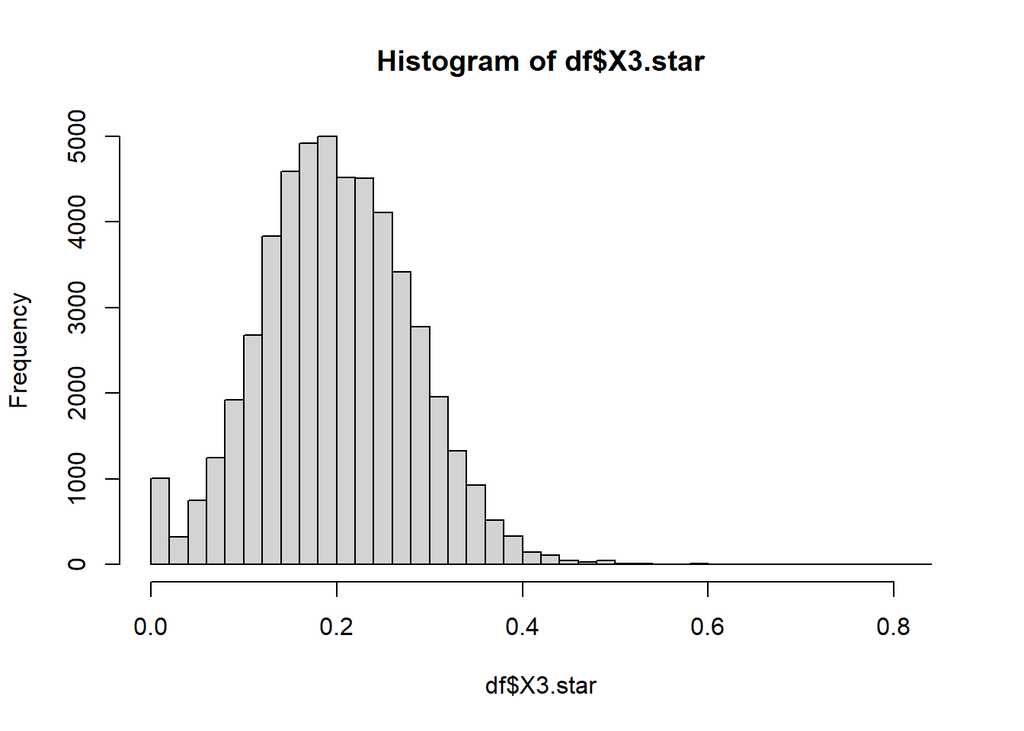

```r
hist(df$X3.star, breaks=50)
```

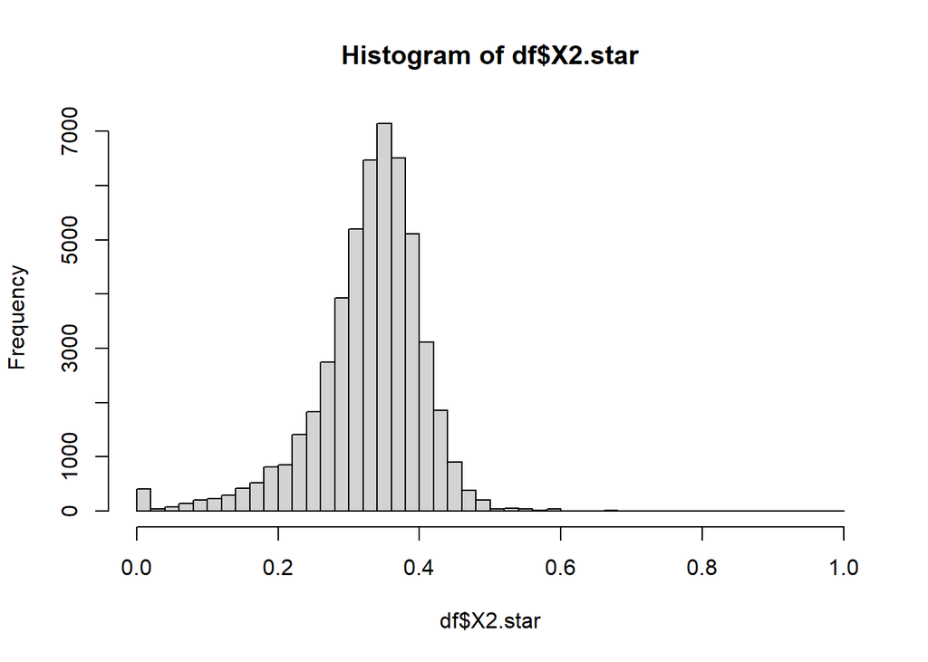

```r
hist(df$X2.star, breaks=50)
```

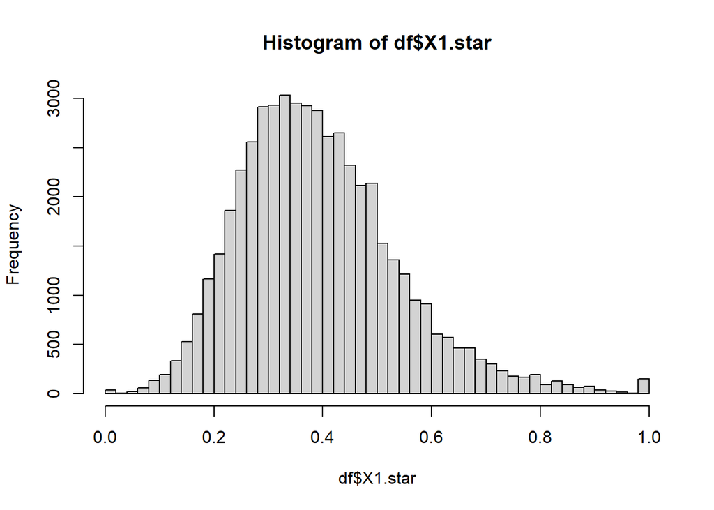

```r
hist(df$X1.star, breaks=50)
```

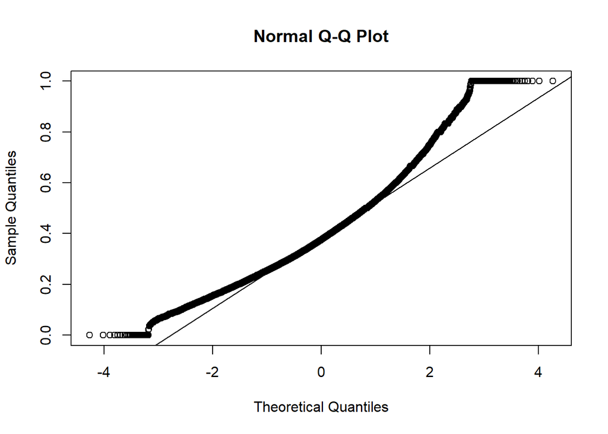

```r
qqnorm(df$X1.star)
qqline(df$X1.star)
```

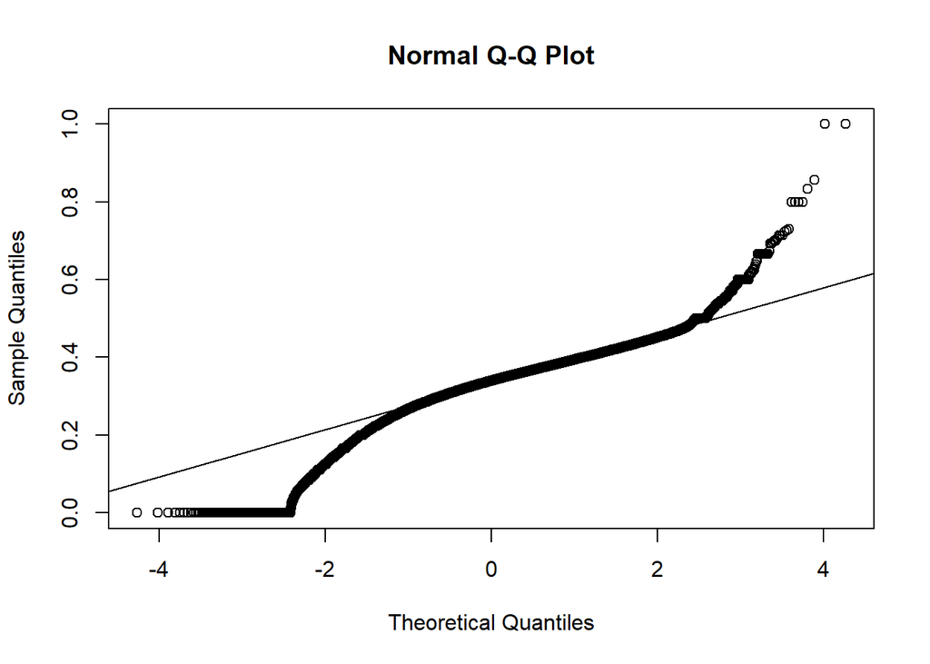

```r
qqnorm(df$X2.star)
qqline(df$X2.star)
```

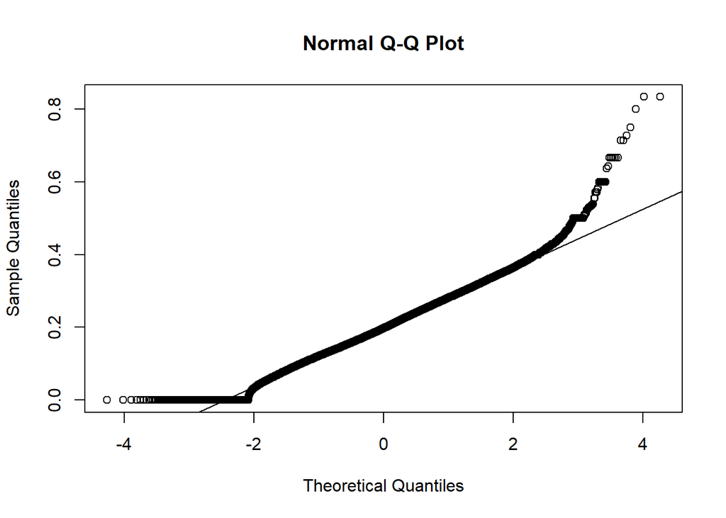

```r
qqnorm(df$X3.star)
qqline(df$X3.star)
```

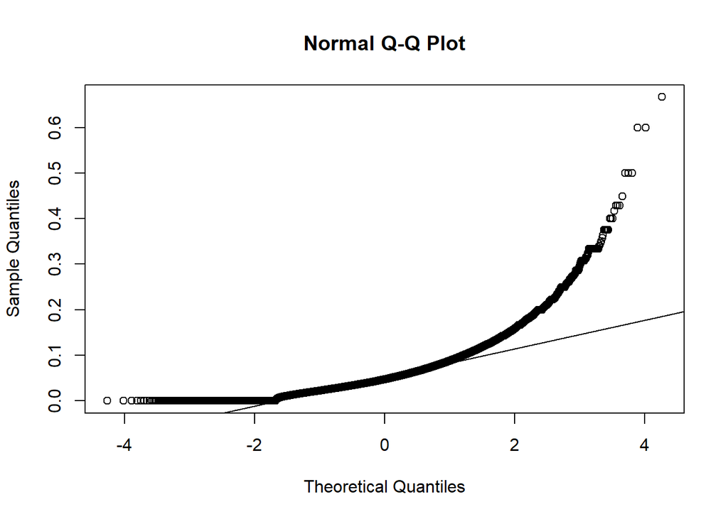

```r
qqnorm(df$X4.star)
qqline(df$X4.star)
```

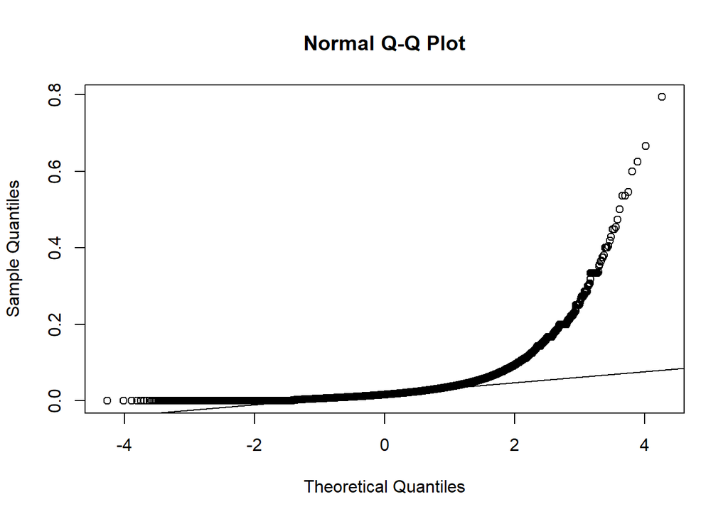

```r
qqnorm(df$X5.star)
qqline(df$X5.star)
```

```r
require(nortest)
lillie.test(df$X1.star)
```

```
##
##  Lilliefors (Kolmogorov-Smirnov) normality test
##
## data:  df$X1.star
## D = 0.04905, p-value < 2.2e-16
```

```r
lillie.test(df$X2.star)
```

```
##
##  Lilliefors (Kolmogorov-Smirnov) normality test
##
## data:  df$X2.star
## D = 0.083257, p-value < 2.2e-16
```

```r
lillie.test(df$X3.star)
```

```
##
##  Lilliefors (Kolmogorov-Smirnov) normality test
##
## data:  df$X3.star
## D = 0.0133, p-value < 2.2e-16
```

```r
lillie.test(df$X4.star)
```

```
##
##  Lilliefors (Kolmogorov-Smirnov) normality test
##
## data:  df$X4.star
## D = 0.10173, p-value < 2.2e-16
```

```r
lillie.test(df$X5.star)
```

```
##
##  Lilliefors (Kolmogorov-Smirnov) normality test
##
## data:  df$X5.star
## D = 0.20151, p-value < 2.2e-16
```

Što se tiče homogenosti varijanci, njihovu jednakost mogli bi provjeriti Bartlettovim testom, ali podatci o ocjenama definitivno nisu normalno distribuirani. Možemo pokušati sa logaritamskom transformacijom podataka

ZAKLJUČAK: Normalnost možemo pokušati postići logaritamskom transformacijom podataka

```r
df <- read.csv("Goodreads-dataset-sanitized-second.csv", header = TRUE, sep=",")
```

Provodimo transformaciju podataka, ali postoji nekoliko problematičnih vrijednosti nula čiji je logaritam - beskonačno, stoga te vrijednosti izbacujemo iz skupa podataka

```r
df = df[!(df$X1.star==0 | df$X2.star==0 |df$X3.star==0 |df$X4.star==0 |df$X5.star==0),]
df = df[!is.na(df$X1.star),]
df = df[!is.na(df$X2.star),]
df = df[!is.na(df$X3.star),]
df = df[!is.na(df$X4.star),]
df = df[!is.na(df$X5.star),]
x = nrow(df)
for(i in 1:x){
  df$X1.star[i] = log(df$X1.star[i])
  df$X2.star[i] = log(df$X2.star[i])
  df$X3.star[i] = log(df$X3.star[i])
  df$X4.star[i] = log(df$X4.star[i])
  df$X5.star[i] = log(df$X5.star[i])
}
head(df)
```

```
##   X Column1             title            series
## 1 1       0 Attracted to Fire
## 2 2       1         Elemental Soul Guardians #2
## 3 3       2      Unbelievable      Port Fare #2
## 4 4       3         Fractured        Fateful #2
## 6 6       5            Marked Soul Guardians #1
## 7 7       6       Wayward Son
##                                                                      author
## 1                                            DiAnn Mills (Goodreads Author)
## 2                                         Kim Richardson (Goodreads Author)
## 3                                          Sherry Gammon (Goodreads Author)
## 4                                          Cheri Schmidt (Goodreads Author)
## 6                                         Kim Richardson (Goodreads Author)
## 7 Tom Pollack (Goodreads Author), John Loftus (Goodreads Author), Jim Alves
##   rating language
```

[output cut: 34 more lines]

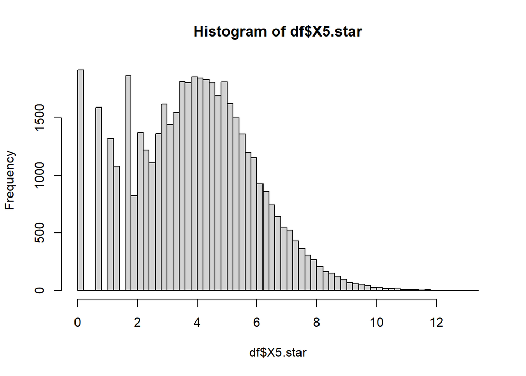

```r
hist(df$X5.star, breaks=50)
```

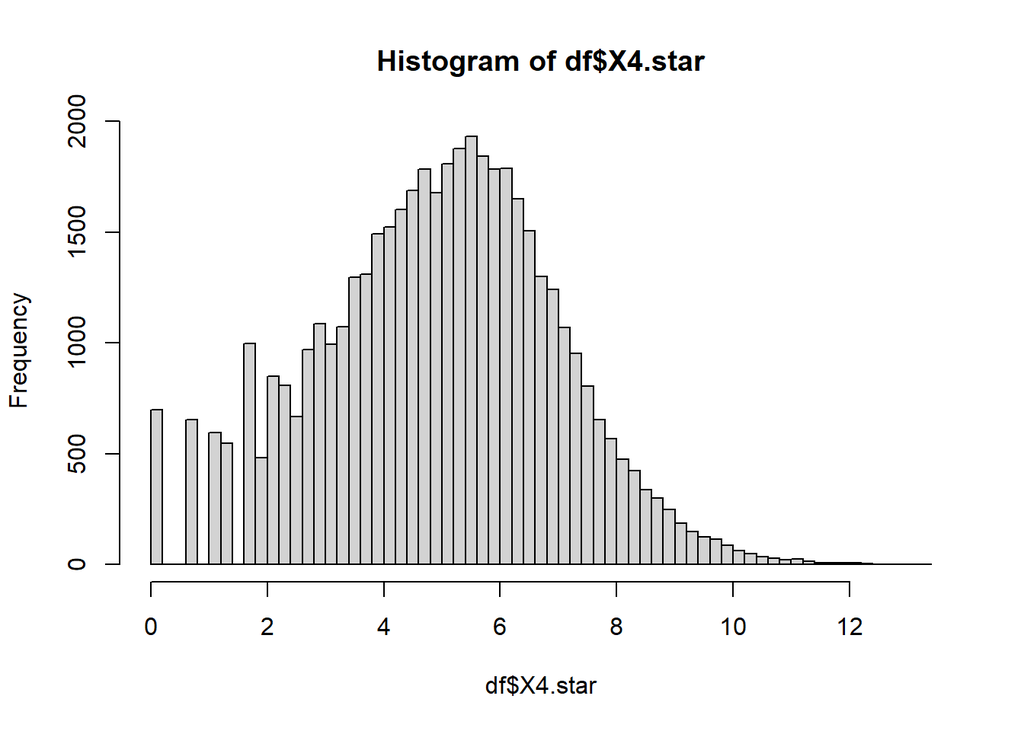

```r
hist(df$X4.star, breaks=50)
```

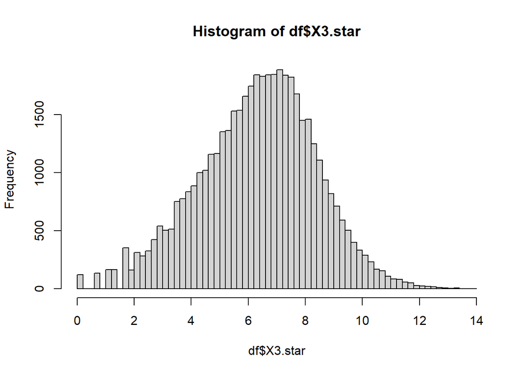

```r
hist(df$X3.star, breaks=50)
```

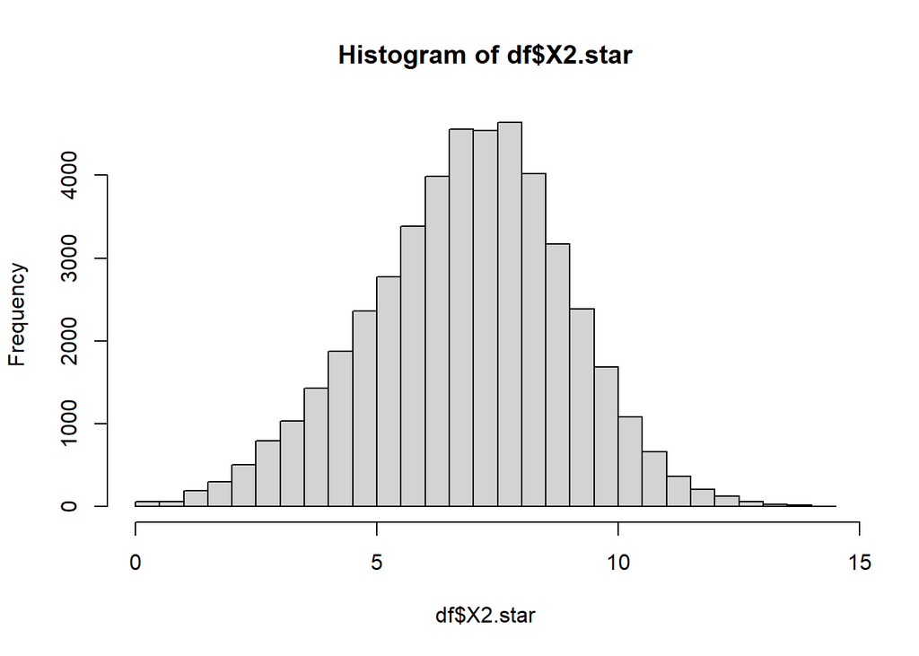

```r
hist(df$X2.star, breaks=50)
```

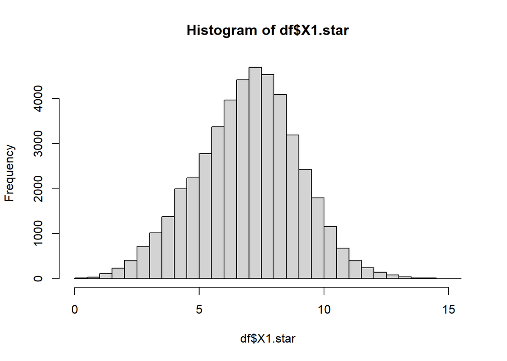

```r
hist(df$X1.star, breaks=50)
```

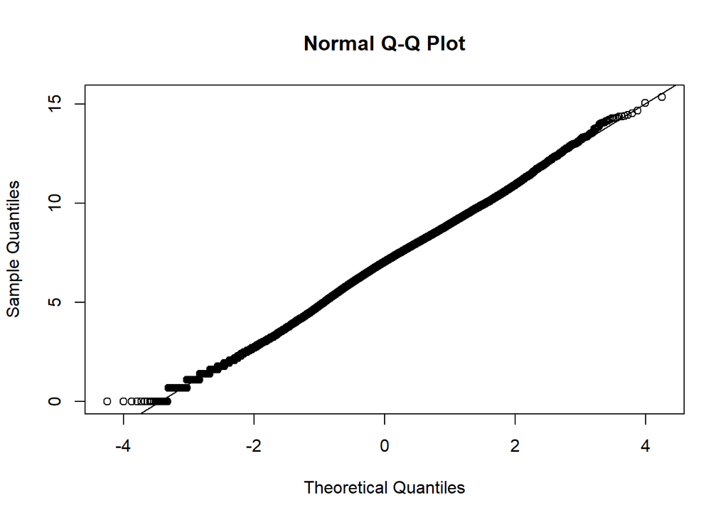

```r
qqnorm(df$X1.star)
qqline(df$X1.star)
```

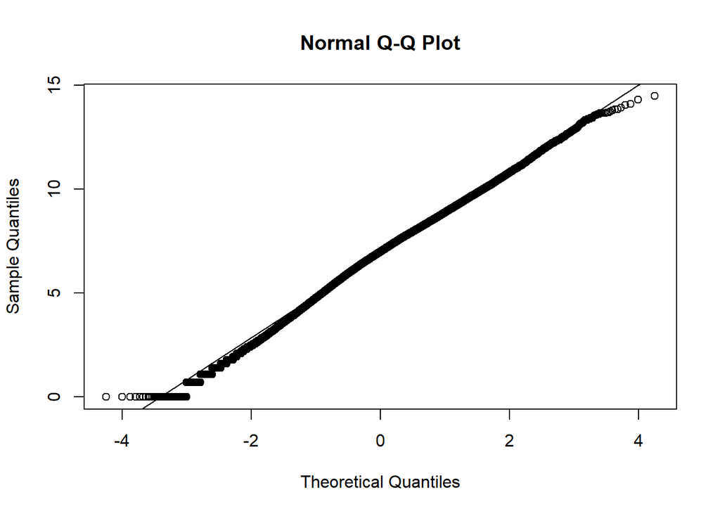

```r
qqnorm(df$X2.star)
qqline(df$X2.star)
```

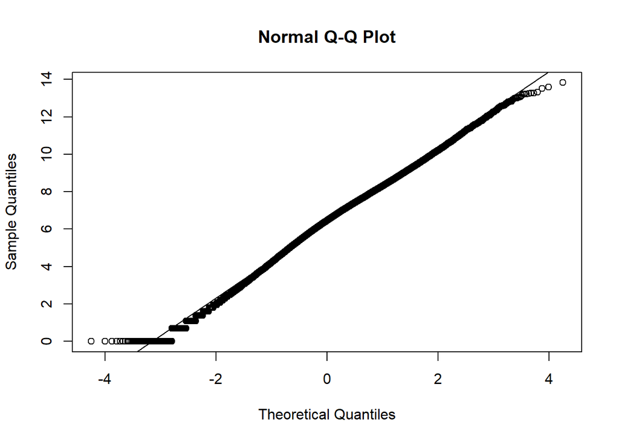

```r
qqnorm(df$X3.star)
qqline(df$X3.star)
```

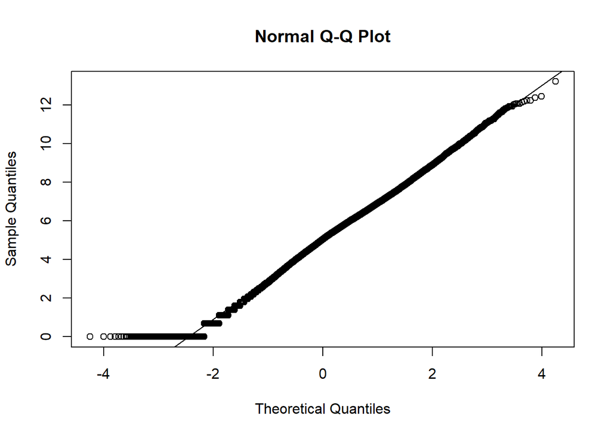

```r
qqnorm(df$X4.star)
qqline(df$X4.star)
```

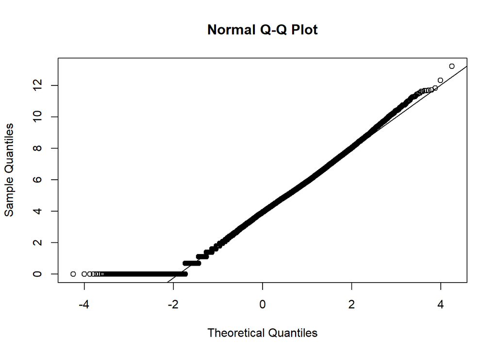

```r
qqnorm(df$X5.star)
qqline(df$X5.star)
```

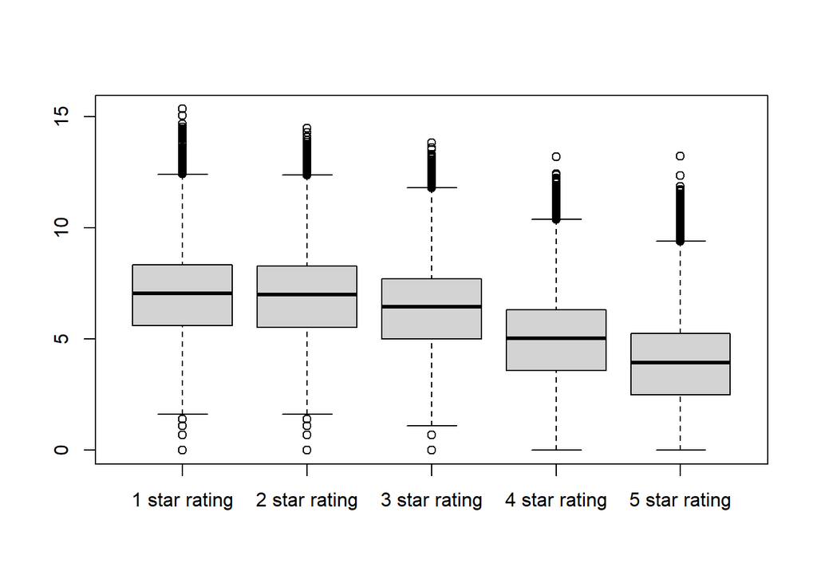

```r
boxplot(df$X1.star, df$X2.star,df$X3.star,df$X4.star,df$X5.star,names=c("1 star rating","2 star rating","3 star rating","4 star rating","5 star rating"))
```

Boxplot sugerira da bi mogla postojati statistički značajna razlika među sredinama. Provodimo ANOVA postupak, jer je on robustan na normalnost

```r
require(nortest)
lillie.test(df$X1.star)
```

```
##
##  Lilliefors (Kolmogorov-Smirnov) normality test
##
## data:  df$X1.star
## D = 0.020686, p-value < 2.2e-16
```

```r
lillie.test(df$X2.star)
```

```
##
##  Lilliefors (Kolmogorov-Smirnov) normality test
##
## data:  df$X2.star
## D = 0.0261, p-value < 2.2e-16
```

```r
lillie.test(df$X3.star)
```

```
##
##  Lilliefors (Kolmogorov-Smirnov) normality test
##
## data:  df$X3.star
## D = 0.027539, p-value < 2.2e-16
```

```r
lillie.test(df$X4.star)
```

```
##
##  Lilliefors (Kolmogorov-Smirnov) normality test
##
## data:  df$X4.star
## D = 0.022641, p-value < 2.2e-16
```

```r
lillie.test(df$X5.star)
```

```
##
##  Lilliefors (Kolmogorov-Smirnov) normality test
##
## data:  df$X5.star
## D = 0.025639, p-value < 2.2e-16
```

Dobivamo malene P-vrijednosti, s obzirom na to da je u skupu podataka velik broj uzoraka.

ANOVA:

```r
aov(X4.star~X1.star+X2.star, data=df)
```

```
## Call:
##    aov(formula = X4.star ~ X1.star + X2.star, data = df)
##
## Terms:
##                   X1.star   X2.star Residuals
## Sum of Squares  152461.33  19336.00  18868.99
## Deg. of Freedom         1         1     46277
##
## Residual standard error: 0.6385454
## Estimated effects may be unbalanced
```

Prethodni dio bavio se ANOVA testom. ANOVA je parametarski test koji prepostavlja homoskedastičnost (homogenost varijanci svih grupa) i normalnost reziduala.

Naslućujemo da je u ovom slučaju bolje koristiti njezinu neparametarsku alternativu - Kruskal-Wallisov test. Nedostatak korištenja neparametarskih testova je manja snaga testa.

Kruskal-Walisov test postavljen je na sljedeći način: H0 (nulta hipoteza) - medijani distribucija svih uzoraka su jednaki H1 (alternativna hipoteza) - barem 2 medijana nisu jednaka

```r
df <- read.csv("Goodreads-dataset-sanitized-second.csv", header = TRUE, sep=",")
```

```r
x1 <- df$X1.star
x2 <- df$X2.star
x3 <- df$X3.star
x4 <- df$X4.star
x5 <- df$X5.star
result <- append(x1, x2)
result <- append(result, x3)
result <- append(result, x4)
result <- append(result, x5)
length(result)
```

```
## [1] 262390
```

```r
grx1 = rep(c("X1.star"),times=length(result)/5)
grx2 = rep(c("X2.star"),times=length(result)/5)
grx3 = rep(c("X3.star"),times=length(result)/5)
grx4 = rep(c("X4.star"),times=length(result)/5)
grx5 = rep(c("X5.star"),times=length(result)/5)
groups <- append(grx1, grx2)
groups <- append(groups, grx3)
groups <- append(groups, grx4)
groups <- append(groups, grx5)
length(groups)
```

```
## [1] 262390
```

```r
ranked_grades <- result
groups <- groups

data <- data.frame(ranked_grades, groups)
head(data)
```

```
##   ranked_grades  groups
## 1           945 X1.star
## 2           801 X1.star
## 3           442 X1.star
## 4           311 X1.star
## 5            16 X1.star
## 6          2109 X1.star
```

```r
kruskal.test(ranked_grades ~ groups,data = data)
```

```
##
##  Kruskal-Wallis rank sum test
##
## data:  ranked_grades by groups
## Kruskal-Wallis chi-squared = 50563, df = 4, p-value < 2.2e-16
```

Stoga, zbog malene p-vrijednosti odbacujemo hipotezu H0 o jednakosti medijana i prihvaćamo hipotezu i da barem 2 medijana nisu jednaka. Za razliku od ANOVA-e, ovaj test je bolji za podatke koje imamo, jer ne zahtjeva pretpostavku normalnosti uzoraka. Snaga testa je zato manja, ali s obzirom da je p-vrijednost vrlo mala, možemo biti sigurni u ispravnost odluke.